# Home Range Analyses: Minimum Convex Polygon

[Brazil Move 2024 - UFMS - Campo Grande](https://eligurarie.github.io/BrazilMove2024)

Nicki Barbour and Elie Gurarie

May 23, 2024

# Goal

> To estimate home ranges with Minimum Convex Polygons and Kernel Density Estimates.

Packages:

```r
library(ggplot2)
library(plyr)
library(sf)
library(adehabitatHR)
library(mapview)
```

# Selecting some animals

```r
load("./data/elk_processed.rda")
head(elk_gps)
```

```
##              datetime       lon      lat   id
## 1 2001-12-13 07:01:00 -115.8043 52.12410 4049
## 2 2001-12-13 09:01:00 -115.8003 52.11762 4049
## 3 2001-12-14 09:01:00 -115.8281 52.09611 4049
## 4 2001-12-14 11:00:00 -115.8318 52.09829 4049
## 5 2001-12-14 17:02:00 -115.8042 52.09482 4049
## 6 2001-12-14 19:01:00 -115.8037 52.12493 4049
```

We’ve picked out 3 individuals that are, largely, non-migratory but resident - and also add some X-Y coordinates:

```r
elk_res <- elk_gps |>
  subset(id %in% c("YL80", "YL91", "YL94")) |>
  mutate(id = droplevels(id))

elk_res_sf <- elk_res |>
  st_as_sf(coords = c("lon","lat"), crs = 4326) |>
  st_transform(32611)

elk_res <- cbind(elk_res, st_coordinates(elk_res_sf))
str(elk_res)
```

```
## 'data.frame':    13425 obs. of  6 variables:
##  $ datetime: POSIXct, format: "2004-02-19 04:00:00" "2004-02-19 05:00:00" ...
##  $ lon     : num  -116 -116 -116 -116 -116 ...
##  $ lat     : num  51.8 51.8 51.8 51.8 51.7 ...
##  $ id      : Factor w/ 3 levels "YL80","YL91",..: 1 1 1 1 1 1 1 1 1 1 ...
##  $ X       : num  598051 597638 597868 597782 597899 ...
##  $ Y       : num  5734228 5734926 5734611 5734807 5734162 ...
```

## Visualize Tracks

Let’s start off by visualizing our selected tracks, using some of the methods we learned in lab 1. We can see that these tracks have a nice “blob” of movement, indicating residential behavior suitable for home range analysis.

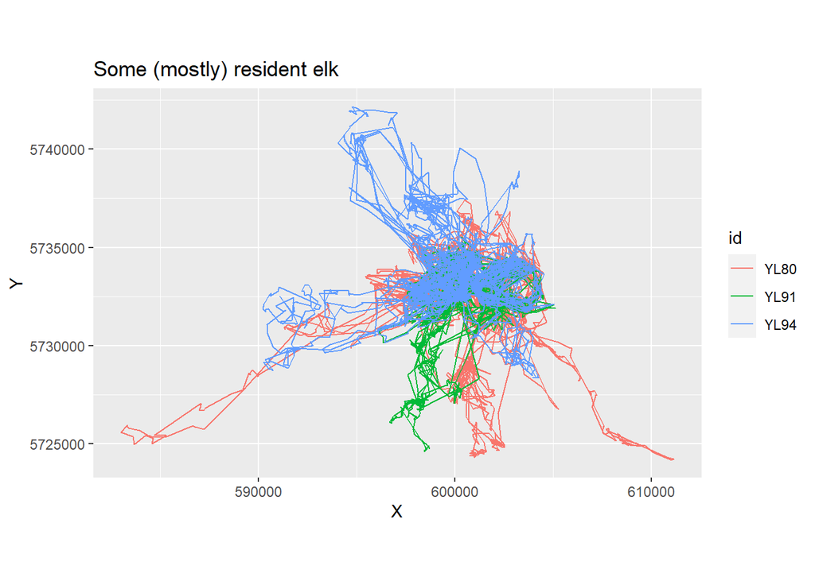

```r
ggplot(data=elk_res, aes(x=X, y=Y, col = id)) +
  geom_path() + coord_fixed() + ggtitle("Some (mostly) resident elk")
```

These are *generally* resident animals, with a LOT of overlap, but also, clearly, some long-distance movements.

Here’s a mapview:

```r
require(dplyr)
elk_tracks <- elk_res_sf |>
  group_by(id) |>
  summarize(do_union=FALSE) |>
  st_cast("LINESTRING")

mapview(elk_tracks,zcol="id")
```

[interactive chart not shown]

# Minimum Convex Polygon

You can get minimum convex polygons using the `adehabitatHR` package, which has many useful functions for homerange analysis.

The MCP method is very simple - essentially, it draws the smallest/tightest polygon around the locations, by 1) calculating the centroid of all the points, 2) calculating the distance from each location/point to this centroid, 3) removing all points that have a distance greater than a specified quantile (usually 95-100 percent) and 4) applying the “convex hull” algorithm to determine the minimum convex polygon for the points.

You can learn more about homerange analysis with this package with the [adehabitat HR vignette](https://cran.r-project.org/web/packages/adehabitatHR/vignettes/adehabitatHR.pdf).

```r
library(adehabitatHR)
```

The `mcp` function from adehabitatHR works on one individual at a time. It also requires that the data first be converted to a “SpatialPoints” structure, a different spatial data type (similar to sf, but using the “sp” package instead).

This function also requires that the user specify the quantile to use for selecting locations for the MCP method - generally 95-100%.

In order to perform our homerange analysis on all of our individuals at once, it will be useful to write a function that takes an individual sf object and a parameter for the percent of points to use for MCP calcuation. The function will return an MCP object, from the `mcp` function.

We’ll start with one animal, and convert it to an `sp` object.

```r
myelk_sf <- elk_res_sf |> subset(id == "YL94")
myelk_sp <- myelk_sf |> as_Spatial()
```

And the `mcp` functions returns the MCP. You can provide the “percentage” which will exclude some points. Just running the function outputs an area (in square km, but that can be adjusted as needed):

```r
(mcp95 <- mcp(myelk_sp, percent = 95, unout = "km2"))
```

```
## Object of class "SpatialPolygonsDataFrame" (package sp):
##
## Number of SpatialPolygons:  1
##
## Variables measured:
##   id     area
## a  a 125.9695
```

```r
(mcp100 <- mcp(myelk_sp, percent = 100, unout = "km2"))
```

```
## Object of class "SpatialPolygonsDataFrame" (package sp):
##
## Number of SpatialPolygons:  1
##
## Variables measured:
##   id     area
## a  a 154.2636
```

Note that the 100% MCP is much larger than the 95% MCP - we’ll see exactly why soon.

You can easily convert this mcp to a simple feature:

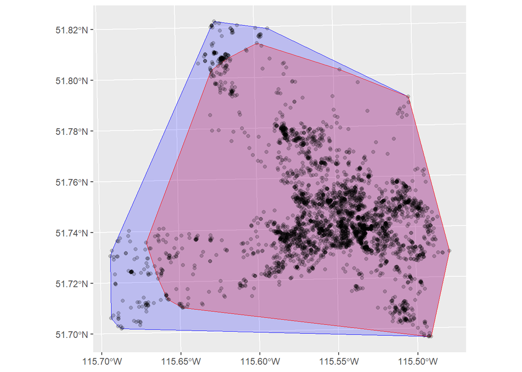

```r
mcp95 <- st_as_sf(mcp95)
mcp100 <- st_as_sf(mcp100)

ggplot() +
  geom_sf(data = mcp100, color = "blue", fill = alpha("blue",.2)) +
    geom_sf(data = mcp95, color = "red", fill = alpha("red",.2)) +
     geom_sf(data = myelk_sf, alpha = 0.2)
```

```r
findMCP <- function(id_sf, percent){
  id_sp <- id_sf |> as_Spatial()
  id_mcp <- mcp(id_sp, percent, unout="km2")
  return(st_as_sf(id_mcp))
}
findMCP(elk_res_sf |> subset(id == "YL80"), 95)
```

```
## Simple feature collection with 1 feature and 2 fields
## Geometry type: POLYGON
## Dimension:     XY
## Bounding box:  xmin: 593874.3 ymin: 5725189 xmax: 606417 ymax: 5737410
## Projected CRS: +proj=utm +zone=11 +datum=WGS84 +units=m +no_defs
##   id     area                       geometry
## a  a 97.18115 POLYGON ((604064 5735250, 6...
```

```r
findMCP(elk_res_sf |> subset(id == "YL91"), 95)
```

```
## Simple feature collection with 1 feature and 2 fields
## Geometry type: POLYGON
## Dimension:     XY
## Bounding box:  xmin: 596113.6 ymin: 5726790 xmax: 605122.7 ymax: 5735530
## Projected CRS: +proj=utm +zone=11 +datum=WGS84 +units=m +no_defs
##   id     area                       geometry
## a  a 49.74813 POLYGON ((605122.7 5731893,...
```

```r
findMCP(elk_res_sf |> subset(id == "YL94"), 95)
```

```
## Simple feature collection with 1 feature and 2 fields
## Geometry type: POLYGON
## Dimension:     XY
## Bounding box:  xmin: 591793.9 ymin: 5728362 xmax: 605053.2 ymax: 5741228
## Projected CRS: +proj=utm +zone=11 +datum=WGS84 +units=m +no_defs
##   id     area                       geometry
## a  a 125.9695 POLYGON ((603260.8 5738889,...
```

You can collect a bunch of simple features into a `SpatialPointsDataframe` and get all the MCP’s at once. Importantly - however - the data can ONLY contain one column - for the ID’s.

```r
elk_sp <- elk_res_sf |> mutate(datetime = NULL) |> as_Spatial(IDs = "id")
elk_mcps <- mcp(elk_sp, percent = 95, unout = "km2") |> st_as_sf()
mapview(elk_mcps, zcol = "id")
```

[interactive chart not shown]

> Are these a good description of the home range? What problems are there?